# R Notebook

### Modeling

Before any modeling is done the data should be standardized for good measure.

The standard = (xi - xbar)/st_dev

The data should also be split into train and test datasets (an 80/20 split will be used).

Separate datasets will be created that use Attack and Sp. Atk, Attack and Defense, and Defense and Sp. Atk. The label will be included in the dataset.

```r
library(tidyr)
library(tidymodels)
```

```r
#scale the data
Attack_SpAtk <- pokemon_reg %>%
  select(Type1, Attack, `Sp. Atk`) %>%
  mutate(Attack = scale(Attack, center = TRUE, scale = TRUE)) %>%
  mutate(`Sp. Atk` = scale(`Sp. Atk`, center = TRUE, scale = TRUE))

Attack_Def <- pokemon_reg %>%
  select(Type1, Attack, Defense) %>%
  mutate(Attack = scale(Attack, center = TRUE, scale = TRUE)) %>%
  mutate(Defense = scale(Defense, center = TRUE, scale = TRUE))

Def_SpAtk <- pokemon_reg %>%
  select(Type1, Defense, `Sp. Atk`) %>%
  mutate(Defense = scale(Defense, center = TRUE, scale = TRUE)) %>%
  mutate(`Sp. Atk` = scale(`Sp. Atk`, center = TRUE, scale = TRUE))

#Create train-test splits
set.seed(123)
Attack_SpAtk_Split <- initial_split(Attack_SpAtk, prop = 0.80)
Attack_SpAtk_Train <- training(Attack_SpAtk_Split)
Attack_SpAtk_Test <- testing(Attack_SpAtk_Split)

Attack_Def_Split <- initial_split(Attack_Def, prop = 0.80)
Attack_Def_Train <- training(Attack_Def_Split)
Attack_Def_Test <- testing(Attack_Def_Split)

Def_SpAtk_Split <- initial_split(Def_SpAtk, prop = 0.80)
Def_SpAtk_Train <- training(Def_SpAtk_Split)
Def_SpAtk_Test <- testing(Def_SpAtk_Split)
```

Now create the decision tree models

```r
library(rpart)
library(rpart.plot)
```

```r
Attack_SpAtk_mdl <- rpart(`Type1` ~ `Attack` + `Sp. Atk`, data = Attack_SpAtk_Train, method = "class")
Attack_Def_mdl <- rpart(`Type1` ~ `Attack` + `Defense`, data = Attack_Def_Train, method = "class")
Def_SpAtk_mdl <- rpart(`Type1` ~ `Defense` + `Sp. Atk`, data = Def_SpAtk_Train, method = "class")
```

Visualize the decision trees

[figure not shown]

```r
rpart.plot(Attack_SpAtk_mdl, fallen.leaves = TRUE)
```

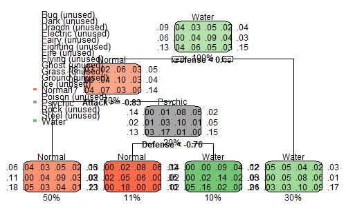

```r
rpart.plot(Attack_Def_mdl, fallen.leaves = TRUE)
```

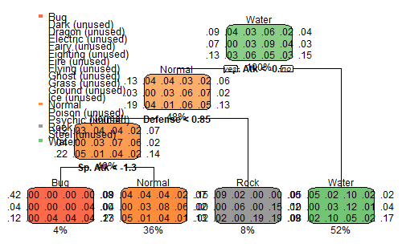

```r
rpart.plot(Def_SpAtk_mdl, fallen.leaves = TRUE)
```

```r
# par(xpd = TRUE)
# plot(Attack_SpAtk_mdl, compress = TRUE)
# text(Attack_SpAtk_mdl, use.n = FALSE)
#
# par(xpd = TRUE)
# plot(Attack_Def_mdl, compress = TRUE)
# text(Attack_Def_mdl, use.n = FALSE)
#
# par(xpd = TRUE)
# plot(Def_SpAtk_mdl, compress = TRUE)
# text(Def_SpAtk_mdl, use.n = FALSE)
```

These plots suggest that the decision tree model is not very robust. However, lets evaluate them before giving a clear answer.

```r
Attack_SpAtk_Test$pred <- predict(Attack_SpAtk_mdl, Attack_SpAtk_Test, type = "class")
table(Attack_SpAtk_Test$pred, Attack_SpAtk_Test$Type1)
```

```
           Bug Dark Dragon Electric Fairy Fighting Fire Flying Ghost Grass Ground Ice Normal Poison
  Bug        1    0      0        0     0        0    0      0     0     0      0   0      5      0
  Dark       0    0      0        0     0        0    0      0     0     0      0   0      0      0
  Dragon     0    0      0        0     0        0    0      0     0     0      0   0      0      0
  Electric   0    0      0        0     0        0    0      0     0     0      0   0      0      0
  Fairy      0    0      0        0     0        0    0      0     0     0      0   0      0      0
  Fighting   0    0      0        0     0        0    0      0     0     0      0   0      0      0
  Fire       0    0      0        0     0        0    0      0     0     0      0   0      0      0
  Flying     0    0      0        0     0        0    0      0     0     0      0   0      0      0
  Ghost      0    0      0        0     0        0    0      0     0     0      0   0      0      0
  Grass      0    0      0        0     0        0    0      0     0     0      0   0      0      0
  Ground     0    0      0        0     0        0    0      0     0     0      0   0      0      0
  Ice        0    0      0        0     0        0    0      0     0     0      0   0      0      0
  Normal     5    4      2        1     1        4    2      0     1     7      5   2     11      1
  Poison     0    0      0        0     0        0    0      0     0     0      0   0      0      0
  Psychic    1    0      0        0     0        0    0      0     2     3      0   0      2      0
  Rock       0    0      0        0     0        0    0      0     0     0      0   0      0      0
  Steel      0    0      0        0     0        0    0      0     0     0      0   0      0      0
  Water      4    3      1        7     2        1    9      0     1    10      0   2      3      3

           Psychic Rock Steel Water
  Bug            1    0     0     1
  Dark           0    0     0     0
  Dragon         0    0     0     0
  Electric       0    0     0     0
  Fairy          0    0     0     0
  Fighting       0    0     0     0
  Fire           0    0     0     0
  Flying         0    0     0     0
  Ghost          0    0     0     0
  Grass          0    0     0     0
  Ground         0    0     0     0
  Ice            0    0     0     0
  Normal         0    4     5     5
  Poison         0    0     0     0
  Psychic        4    1     0     2
  Rock           0    0     0     0
  Steel          0    0     0     0
  Water          5    1     1    11
```

```r
print("Accuracy: ", )
```

```
[1] "Accuracy: "
```

```r
mean(Attack_SpAtk_Test$pred == Attack_SpAtk_Test$Type1)
```

```
[1] 0.1836735
```

Indeed the accuracy is quite low, at 18.3% for the Attack and Sp. Atk model. Next the Attack and Defense model will be evaluated.

```r
Attack_Def_Test$pred <- predict(Attack_Def_mdl, Attack_Def_Test, type = "class")
table(Attack_Def_Test$pred, Attack_Def_Test$Type1)
```

```
           Bug Dark Dragon Electric Fairy Fighting Fire Flying Ghost Grass Ground Ice Normal Poison
  Bug        0    0      0        0     0        0    0      0     0     0      0   0      0      0
  Dark       0    0      0        0     0        0    0      0     0     0      0   0      0      0
  Dragon     0    0      0        0     0        0    0      0     0     0      0   0      0      0
  Electric   0    0      0        0     0        0    0      0     0     0      0   0      0      0
  Fairy      0    0      0        0     0        0    0      0     0     0      0   0      0      0
  Fighting   0    0      0        0     0        0    0      0     0     0      0   0      0      0
  Fire       0    0      0        0     0        0    0      0     0     0      0   0      0      0
  Flying     0    0      0        0     0        0    0      0     0     0      0   0      0      0
  Ghost      0    0      0        0     0        0    0      0     0     0      0   0      0      0
  Grass      0    0      0        0     0        0    0      0     0     0      0   0      0      0
  Ground     0    0      0        0     0        0    0      0     0     0      0   0      0      0
  Ice        0    0      0        0     0        0    0      0     0     0      0   0      0      0
  Normal     9    8      2        6     2        1    9      0     2     8      5   2     14      5
  Poison     0    0      0        0     0        0    0      0     0     0      0   0      0      0
  Psychic    0    0      0        0     0        0    0      0     0     0      0   0      0      0
  Rock       0    0      0        0     0        0    0      0     0     0      0   0      0      0
  Steel      0    0      0        0     0        0    0      0     0     0      0   0      0      0
  Water      5    0      1        3     0        1    0      0     3     5      2   3      3      1

           Psychic Rock Steel Water
  Bug            0    0     0     0
  Dark           0    0     0     0
  Dragon         0    0     0     0
  Electric       0    0     0     0
  Fairy          0    0     0     0
  Fighting       0    0     0     0
  Fire           0    0     0     0
  Flying         0    0     0     0
  Ghost          0    0     0     0
  Grass          0    0     0     0
  Ground         0    0     0     0
  Ice            0    0     0     0
  Normal         6    2     1    17
  Poison         0    0     0     0
  Psychic        0    0     0     0
  Rock           0    0     0     0
  Steel          0    0     0     0
  Water          3    9     4     5
```

```r
print("Accuracy: ", )
```

```
[1] "Accuracy: "
```

```r
mean(Attack_Def_Test$pred == Attack_Def_Test$Type1)
```

```
[1] 0.1292517
```

The accuracy for this model is 12.9%. Finally, let’s examine the Defense and Sp. Atk model

```r
Def_SpAtk_Test$pred <- predict(Def_SpAtk_mdl, Def_SpAtk_Test, type = "class")
table(Def_SpAtk_Test$pred, Def_SpAtk_Test$Type1)
```

```
           Bug Dark Dragon Electric Fairy Fighting Fire Flying Ghost Grass Ground Ice Normal Poison
  Bug        2    0      0        0     0        0    0      0     0     1      0   0      2      0
  Dark       0    0      0        0     0        0    0      0     0     0      0   0      0      0
  Dragon     0    0      0        0     0        0    0      0     0     0      0   0      0      0
  Electric   0    0      0        0     0        0    0      0     0     0      0   0      0      0
  Fairy      0    0      0        0     0        0    0      0     0     0      0   0      0      0
  Fighting   0    0      0        0     0        0    0      0     0     0      0   0      0      0
  Fire       0    0      0        0     0        0    0      0     0     0      0   0      0      0
  Flying     0    0      0        0     0        0    0      0     0     0      0   0      0      0
  Ghost      0    0      0        0     0        0    0      0     0     0      0   0      0      0
  Grass      0    0      0        0     0        0    0      0     0     0      0   0      0      0
  Ground     0    0      0        0     0        0    0      0     0     0      0   0      0      0
  Ice        0    0      0        0     0        0    0      0     0     0      0   0      0      0
  Normal     9    2      0        0     2        4    0      1     2     4      3   1     13      4
  Poison     0    0      0        0     0        0    0      0     0     0      0   0      0      0
  Psychic    0    0      0        0     0        0    0      0     0     0      0   0      0      0
  Rock       2    0      0        0     0        0    0      0     2     2      0   0      1      0
  Steel      0    0      0        0     0        0    0      0     0     0      0   0      0      0
  Water      4    1      3        2     2        1    7      0     8     8      2   3      3      5

           Psychic Rock Steel Water
  Bug            0    1     0     1
  Dark           0    0     0     0
  Dragon         0    0     0     0
  Electric       0    0     0     0
  Fairy          0    0     0     0
  Fighting       0    0     0     0
  Fire           0    0     0     0
  Flying         0    0     0     0
  Ghost          0    0     0     0
  Grass          0    0     0     0
  Ground         0    0     0     0
  Ice            0    0     0     0
  Normal         3    1     0     3
  Poison         0    0     0     0
  Psychic        0    0     0     0
  Rock           0    3     3     0
  Steel          0    0     0     0
  Water          5    3     2    16
```

```r
print("Accuracy: ", )
```

```
[1] "Accuracy: "
```

```r
mean(Def_SpAtk_Test$pred == Def_SpAtk_Test$Type1)
```

```
[1] 0.2312925
```

This model had an accuracy of 23.1% which is higher than the other models, but still very low overall.

**Next a k-NN model will be tried**

```r
library(class)
```

```r
pokemon_types <- Attack_SpAtk_Train$Type1

Attack_SpAtk_Pred <- knn(Attack_SpAtk_Train[,2:3], Attack_SpAtk_Test[,2:3], cl = pokemon_types, k = 24)
Attack_Def_Pred <- knn(Attack_Def_Train[,2:3], Attack_Def_Test[,2:3], cl = pokemon_types, k = 24)
Def_SpAtk_Pred <- knn(Def_SpAtk_Train[,2:3], Def_SpAtk_Test[,2:3], cl = pokemon_types, k = 24)
```

```r
Attack_SpAtk_Actual <- Attack_SpAtk_Test$Type1
Attack_Def_Actual <- Attack_Def_Test$Type1
Def_SpAtk_Actual <- Def_SpAtk_Test$Type1
```

Attack and Sp. Atk:

```r
table(Attack_SpAtk_Pred, Attack_SpAtk_Actual)
```

```
                 Attack_SpAtk_Actual
Attack_SpAtk_Pred Bug Dark Dragon Electric Fairy Fighting Fire Flying Ghost Grass Ground Ice Normal
         Bug        2    0      0        0     0        0    0      0     0     0      1   0      5
         Dark       0    0      0        0     0        0    0      0     0     0      0   0      0
         Dragon     1    0      0        0     0        1    0      0     0     0      0   0      0
         Electric   1    0      0        3     1        0    1      0     0     2      0   0      0
         Fairy      0    0      0        0     0        0    0      0     0     0      0   0      0
         Fighting   0    0      0        0     0        0    0      0     0     0      0   0      0
         Fire       0    1      0        0     0        0    1      0     0     0      0   0      0
         Flying     0    0      0        0     0        0    0      0     0     0      0   0      0
         Ghost      1    0      0        0     0        0    1      0     0     0      0   0      1
         Grass      0    0      0        0     0        0    1      0     0     1      0   0      1
         Ground     0    0      0        0     0        1    0      0     0     0      0   0      1
         Ice        0    0      0        0     0        0    0      0     0     0      0   0      0
         Normal     3    3      2        0     1        3    0      0     0     3      4   3      7
         Poison     0    0      0        1     0        0    0      0     0     0      0   0      0
         Psychic    0    0      0        0     0        0    0      0     2     1      0   1      2
         Rock       0    0      1        0     0        0    0      0     0     1      0   0      0
         Steel      0    0      0        0     0        0    0      0     0     0      0   0      0
         Water      3    3      0        4     1        0    7      0     2    12      0   0      4
                 Attack_SpAtk_Actual
Attack_SpAtk_Pred Poison Psychic Rock Steel Water
         Bug           0       0    0     1     1
         Dark          0       0    0     0     0
         Dragon        0       0    0     0     0
         Electric      0       4    0     0     2
         Fairy         0       0    0     0     0
         Fighting      0       0    0     0     0
         Fire          0       1    0     0     0
         Flying        0       0    0     0     0
         Ghost         0       0    0     1     1
         Grass         0       2    0     0     1
         Ground        0       0    0     0     0
         Ice           0       0    0     0     0
         Normal        2       1    3     3     2
         Poison        0       0    0     0     0
         Psychic       0       2    1     0     1
         Rock          0       0    1     1     1
         Steel         0       0    0     0     0
         Water         2       0    1     0    10
```

```r
mean(Attack_SpAtk_Pred == Attack_SpAtk_Actual)
```

```
[1] 0.1836735
```

Attack and Defense:

```r
table(Attack_Def_Pred, Attack_Def_Actual)
```

```
               Attack_Def_Actual
Attack_Def_Pred Bug Dark Dragon Electric Fairy Fighting Fire Flying Ghost Grass Ground Ice Normal Poison
       Bug        2    1      0        0     1        0    2      0     1     3      2   1      3      3
       Dark       0    0      0        0     0        0    0      0     0     0      0   0      0      0
       Dragon     0    0      0        0     0        0    0      0     0     0      0   0      0      0
       Electric   0    0      0        0     0        0    0      0     0     0      0   0      0      0
       Fairy      0    0      0        0     0        0    0      0     0     0      0   0      0      0
       Fighting   0    0      0        0     0        0    0      0     0     0      0   1      0      0
       Fire       1    1      0        1     0        0    0      0     0     1      0   0      0      0
       Flying     0    0      0        0     0        0    0      0     0     0      0   0      0      0
       Ghost      1    0      0        0     0        0    0      0     1     1      0   0      1      0
       Grass      2    1      0        0     0        1    0      0     0     0      1   0      2      0
       Ground     0    1      0        0     0        0    0      0     0     0      0   0      0      0
       Ice        0    0      0        0     0        0    0      0     0     0      0   0      0      0
       Normal     2    1      2        4     1        0    4      0     0     2      2   2      5      3
       Poison     0    0      0        0     0        0    0      0     0     0      0   0      1      0
       Psychic    0    0      0        0     0        0    0      0     0     0      0   0      0      0
       Rock       1    1      1        1     0        0    3      0     0     1      0   0      1      0
       Steel      0    0      0        0     0        0    0      0     0     0      0   0      0      0
       Water      5    2      0        3     0        1    0      0     3     5      2   1      4      0
               Attack_Def_Actual
Attack_Def_Pred Psychic Rock Steel Water
       Bug            2    0     0     4
       Dark           0    0     0     0
       Dragon         0    0     0     0
       Electric       0    0     0     1
       Fairy          0    0     0     0
       Fighting       0    0     0     2
       Fire           0    0     0     0
       Flying         0    0     0     0
       Ghost          1    0     0     1
       Grass          1    0     1     1
       Ground         0    0     0     0
       Ice            0    0     0     0
       Normal         3    4     1     3
       Poison         0    0     0     0
       Psychic        0    0     0     0
       Rock           0    0     0     3
       Steel          0    0     0     0
       Water          2    7     3     7
```

```r
mean(Attack_Def_Pred == Attack_Def_Actual)
```

```
[1] 0.1020408
```

Defense and Sp. Atk:

```r
table(Def_SpAtk_Pred, Def_SpAtk_Actual)
```

```
              Def_SpAtk_Actual
Def_SpAtk_Pred Bug Dark Dragon Electric Fairy Fighting Fire Flying Ghost Grass Ground Ice Normal Poison
      Bug        4    0      0        0     1        1    2      0     3     2      1   0      2      0
      Dark       0    0      0        0     0        0    0      0     0     0      0   0      0      0
      Dragon     1    0      0        0     0        0    0      0     0     0      0   0      0      0
      Electric   0    0      0        0     0        0    0      0     0     0      1   0      0      0
      Fairy      0    0      0        0     0        0    0      0     0     0      0   0      0      0
      Fighting   1    0      0        0     0        1    0      0     0     2      0   0      2      0
      Fire       0    0      0        0     0        0    1      0     1     1      0   0      0      1
      Flying     0    0      0        0     0        0    0      0     0     0      0   0      0      0
      Ghost      1    0      0        0     0        0    0      0     0     0      0   1      0      0
      Grass      0    0      0        0     0        0    2      0     0     1      0   0      1      0
      Ground     0    0      0        0     0        0    0      0     0     0      0   0      0      0
      Ice        0    0      0        0     0        0    0      0     0     0      0   0      0      0
      Normal     1    2      2        0     2        1    2      0     2     3      0   1      9      2
      Poison     0    0      0        0     0        0    0      0     0     0      0   0      0      0
      Psychic    0    0      0        0     0        0    0      1     0     0      0   0      1      0
      Rock       1    0      0        0     0        0    0      0     0     0      0   0      0      0
      Steel      0    0      0        0     0        0    0      0     0     0      0   0      0      0
      Water      8    1      1        2     1        2    0      0     6     6      3   2      4      6
              Def_SpAtk_Actual
Def_SpAtk_Pred Psychic Rock Steel Water
      Bug            0    1     0     3
      Dark           0    0     0     0
      Dragon         1    0     0     0
      Electric       0    0     0     0
      Fairy          0    0     0     0
      Fighting       0    0     0     0
      Fire           0    0     0     1
      Flying         0    0     0     0
      Ghost          1    1     0     0
      Grass          0    0     0     3
      Ground         0    0     0     0
      Ice            0    0     0     0
      Normal         1    2     1     5
      Poison         0    0     0     0
      Psychic        1    0     0     0
      Rock           0    0     0     0
      Steel          0    1     0     0
      Water          4    3     4     8
```

```r
mean(Def_SpAtk_Pred == Def_SpAtk_Actual)
```

```
[1] 0.170068
```

Overall, kNN appears to have worse performance than the decision tree.

**Next, a random forest will be tried**

```r
library(randomForest)
```

```r
names(Attack_SpAtk_Train)[names(Attack_SpAtk_Train) == "Sp. Atk"] <- "SpAtk"
names(Def_SpAtk_Train)[names(Def_SpAtk_Train) == "Sp. Atk"] <- "SpAtk"

Attack_SpAtk_rf <- randomForest(`Type1` ~ `Attack` + `SpAtk`, data = Attack_SpAtk_Train)
Attack_Def_rf <- randomForest(`Type1` ~ `Attack` + `Defense`, data = Attack_Def_Train)
Def_SpAtk_rf <- randomForest(`Type1` ~ `Defense` + `SpAtk`, data = Def_SpAtk_Train)
```

```r
names(Attack_SpAtk_Test)[names(Attack_SpAtk_Test) == "Sp. Atk"] <- "SpAtk"
names(Def_SpAtk_Test)[names(Def_SpAtk_Test) == "Sp. Atk"] <- "SpAtk"

Attack_SpAtk_Test$pred_rf <- predict(Attack_SpAtk_rf, newdata = Attack_SpAtk_Test)
Attack_Def_Test$pred_rf <- predict(Attack_Def_rf, newdata = Attack_Def_Test)
Def_SpAtk_Test$pred_rf <- predict(Def_SpAtk_rf, newdata = Def_SpAtk_Test)
```

```r
Attack_SpAtk_rf_Actual <- Attack_SpAtk_Test$Type1
Attack_Def_rf_Actual <- Attack_Def_Test$Type1
Def_SpAtk_rf_Actual <- Def_SpAtk_Test$Type1
```

Assessing Attack and Sp. Atk with random forest:

```r
table(Attack_SpAtk_Test$pred_rf, Attack_SpAtk_rf_Actual)
```

```
          Attack_SpAtk_rf_Actual
           Bug Dark Dragon Electric Fairy Fighting Fire Flying Ghost Grass Ground Ice Normal Poison
  Bug        3    2      1        0     0        1    1      0     0     1      2   1      1      0
  Dark       1    0      0        0     0        0    0      0     0     0      0   0      0      0
  Dragon     1    1      0        0     0        0    1      0     0     0      0   0      0      0
  Electric   1    0      0        1     0        0    1      0     1     1      0   0      2      0
  Fairy      0    0      0        1     1        0    0      0     0     0      0   0      0      0
  Fighting   0    0      1        1     0        1    0      0     0     0      1   1      1      0
  Fire       0    0      0        0     0        0    1      0     0     1      0   0      0      0
  Flying     0    0      0        0     1        0    0      0     0     0      0   0      0      0
  Ghost      0    0      0        0     0        0    0      0     0     1      0   0      1      1
  Grass      0    1      0        1     0        0    2      0     1     2      0   0      1      0
  Ground     0    1      0        0     0        1    0      0     0     0      0   0      1      0
  Ice        2    0      0        0     0        0    0      0     1     0      0   0      0      0
  Normal     1    1      1        2     1        1    0      0     0     5      2   1      7      0
  Poison     0    0      0        0     0        0    0      0     0     1      0   0      2      0
  Psychic    0    0      0        0     0        0    0      0     0     4      0   0      2      1
  Rock       1    0      0        0     0        0    1      0     0     1      0   1      0      0
  Steel      0    0      0        0     0        1    0      0     0     0      0   0      0      0
  Water      1    1      0        2     0        0    4      0     1     3      0   0      3      2
          Attack_SpAtk_rf_Actual
           Psychic Rock Steel Water
  Bug            0    0     1     1
  Dark           0    0     0     0
  Dragon         0    0     0     0
  Electric       2    1     0     2
  Fairy          1    0     0     1
  Fighting       0    0     0     0
  Fire           0    0     0     1
  Flying         0    0     0     0
  Ghost          2    1     0     1
  Grass          0    0     0     0
  Ground         0    1     0     0
  Ice            0    0     0     1
  Normal         0    2     4     4
  Poison         0    0     0     2
  Psychic        2    0     0     0
  Rock           2    1     1     0
  Steel          0    0     0     0
  Water          1    0     0     6
```

```r
print("Accuracy: ")
```

```
[1] "Accuracy: "
```

```r
mean(Attack_SpAtk_Test$pred_rf == Attack_SpAtk_rf_Actual)
```

```
[1] 0.170068
```

Assessing Attack and Defense with random forest:

```r
table(Attack_Def_Test$pred_rf, Attack_Def_Actual)
```

```
          Attack_Def_Actual
           Bug Dark Dragon Electric Fairy Fighting Fire Flying Ghost Grass Ground Ice Normal Poison
  Bug        3    0      0        0     0        0    1      0     0     3      1   0      2      0
  Dark       0    1      0        0     0        0    0      0     0     1      0   1      1      0
  Dragon     0    0      0        0     0        0    0      0     0     0      0   0      1      0
  Electric   0    0      1        2     0        0    2      0     0     0      0   0      0      0
  Fairy      0    0      0        0     0        0    0      0     0     0      1   0      0      0
  Fighting   1    1      0        0     0        1    0      0     0     0      0   0      0      0
  Fire       1    3      0        0     0        0    2      0     1     0      0   0      1      0
  Flying     0    0      0        0     0        0    0      0     0     0      0   0      0      0
  Ghost      0    0      0        0     0        0    1      0     2     1      0   0      1      0
  Grass      2    2      0        1     0        0    1      0     1     2      1   2      2      2
  Ground     0    0      0        0     0        0    0      0     0     0      0   0      0      0
  Ice        1    1      0        0     0        0    0      0     0     0      1   0      1      0
  Normal     2    0      1        3     0        1    2      0     0     1      2   2      5      1
  Poison     0    0      0        0     0        0    0      0     0     0      0   0      0      0
  Psychic    0    0      0        1     0        0    0      0     0     0      0   0      0      0
  Rock       0    0      0        0     0        0    0      0     0     0      1   0      1      0
  Steel      1    0      1        0     0        0    0      0     0     2      0   0      0      0
  Water      3    0      0        2     2        0    0      0     1     3      0   0      2      3
          Attack_Def_Actual
           Psychic Rock Steel Water
  Bug            1    1     1     1
  Dark           0    1     0     1
  Dragon         0    0     0     0
  Electric       0    0     0     2
  Fairy          0    0     0     0
  Fighting       1    0     0     1
  Fire           0    1     0     2
  Flying         0    0     0     0
  Ghost          0    0     0     0
  Grass          0    1     0     4
  Ground         0    1     0     2
  Ice            0    0     0     1
  Normal         0    0     0     4
  Poison         0    0     0     0
  Psychic        4    0     0     1
  Rock           0    2     0     2
  Steel          0    4     2     0
  Water          3    0     2     1
```

```r
print("Accuracy: ")
```

```
[1] "Accuracy: "
```

```r
mean(Attack_Def_Test$pred_rf == Attack_Def_Actual)
```

```
[1] 0.1836735
```

Assessing Defense and Sp. Atk:

```r
table(Def_SpAtk_Test$pred_rf, Def_SpAtk_Actual)
print("Accuracy: ")
mean(Def_SpAtk_Test$pred_rf == Def_SpAtk_Actual)
```

[output not shown]

**Therefore, this is evidence that no two stats alone can predict the type of Pokemon. However, to know for certain, a decision tree model with all the features should be built, and the corresponding feature importance should be calculated.**

### Decision Tree Model With All Pokemon Stats Included

```r
#Create a new train test split for Pokemon with all features except legendary status
pokemon_all_stats <- pokemon_reg %>%
  select(-Name, -`Type 2`, -Total, -Generation, -Legendary)

set.seed(456)
train_test_split <- initial_split(pokemon_all_stats, prop = 0.80)
pokemon_all_stats_train <- training(train_test_split)
pokemon_all_stats_test <- testing(train_test_split)
```

[figure not shown]

```r
# Create a decision tree model
pokemon_all_stats_mdl <- rpart(`Type1` ~ ., data = pokemon_all_stats_train, method = 'class')
rpart.plot(pokemon_all_stats_mdl, fallen.leaves = TRUE)
```

```r
pokemon_all_stats_test$pred <- predict(pokemon_all_stats_mdl, pokemon_all_stats_test, type = "class")

table(pokemon_all_stats_test$pred, pokemon_all_stats_test$Type1)
print("Accuracy: ")
mean(pokemon_all_stats_test$pred == pokemon_all_stats_test$Type1)
```

[output not shown]

```r
pokemon_all_stats_train$pred <- predict(pokemon_all_stats_mdl, pokemon_all_stats_train, type = "class")
table(pokemon_all_stats_train$pred, pokemon_all_stats_train$Type1)
print("Accuracy: ")
mean(pokemon_all_stats_train$pred == pokemon_all_stats_train$Type1)
```

[output not shown]

The next question to investigate is what would the model accuracy be if the data was more balanced?

The reason this question is being asked is because the model notably makes a lot of Water type predictions. **What is the proportion of water types being represented as opposed other types?**

```r
ggplot(pokemon_all_stats, aes(y = `Type1`)) +
  geom_bar(fill = "blue")
```

[output not shown]

```r
# Merge the types together
pokemon_alltypes_combined <- pokemon_reg %>%
  mutate(`Type1` = as.character(`Type1`)) %>%
  mutate(`Type 2` = as.character(`Type 2`)) %>%
  mutate(Type = paste(`Type1`, `Type 2`, sep = ", ")) %>%
  mutate(Type = gsub(", NA", "", Type))

# Visualize the count of each type
ggplot(pokemon_alltypes_combined, aes(y = Type)) +
  geom_bar(fill = "blue")
```

[output not shown]

```r
pokemon_combined_type_counts_filtered <- pokemon_alltypes_combined %>%
  group_by(Type) %>%
  count() %>%
  filter(n >= 10)

ggplot(pokemon_combined_type_counts_filtered, aes(x = n, y = Type)) +
  geom_col(fill = "blue")
```

[output not shown]

Let’s investigate what effect this has on stat separation particularly for Attack, Defense, Sp. Attack, and Speed to see if this will change any of the modeling decisions. We will still only display types that have at least 10 members in them for simplicity.

```r
types_more_than_10_pokemon <- pokemon_combined_type_counts_filtered$Type

pokemon_alltypes_combined_filtered <- pokemon_alltypes_combined %>%
  filter(Type %in% types_more_than_10_pokemon)

ggplot(pokemon_alltypes_combined_filtered, aes(y = Type, x = HP)) +
  geom_boxplot(fill = "green") +
  geom_vline(aes(xintercept = median(HP)), linetype = 2) +
  labs(caption = "Dashed line inidcates the median HP stat for all Pokemon") +
  ggtitle("Attack stat boxplots segmented by Pokemon Type")

ggplot(pokemon_alltypes_combined_filtered, aes(y = Type, x = Attack)) +
  geom_boxplot(fill = "orange") +
  geom_vline(aes(xintercept = median(Attack)), linetype = 2) +
  labs(caption = "Dashed line inidcates the median Attack stat for all Pokemon") +
  ggtitle("Attack stat boxplots segmented by Pokemon Type")

ggplot(pokemon_alltypes_combined_filtered, aes(y = Type, x = Defense)) +
  geom_boxplot(fill = "blue") +
  geom_vline(aes(xintercept = median(Defense)), linetype = 2) +
  labs(caption = "Dashed line inidcates the median Defense stat for all Pokemon") +
  ggtitle("Attack stat boxplots segmented by Pokemon Type")

ggplot(pokemon_alltypes_combined_filtered, aes(y = Type, x = `Sp. Atk`)) +
  geom_boxplot(fill = "red") +
  geom_vline(aes(xintercept = median(`Sp. Atk`)), linetype = 2) +
  labs(caption = "Dashed line inidcates the median Sp. Atk stat for all Pokemon") +
  ggtitle("Attack stat boxplots segmented by Pokemon Type")

ggplot(pokemon_alltypes_combined_filtered, aes(y = Type, x = `Sp. Def`)) +
  geom_boxplot(fill = "purple") +
  geom_vline(aes(xintercept = median(`Sp. Def`)), linetype = 2) +
  labs(caption = "Dashed line inidcates the median Sp. Def stat for all Pokemon") +
  ggtitle("Attack stat boxplots segmented by Pokemon Type")

ggplot(pokemon_alltypes_combined_filtered, aes(y = Type, x = Speed)) +
  geom_boxplot(fill = "yellow") +
  geom_vline(aes(xintercept = median(Speed)), linetype = 2) +
  labs(caption = "Dashed line inidcates the median Speed stat for all Pokemon") +
  ggtitle("Attack stat boxplots segmented by Pokemon Type")
```

[output not shown]

```r
print("Defense")
```

```
[1] "Defense"
```

```r
kruskal.test(
  Defense ~ Type,
  data = pokemon_alltypes_combined_filtered
)
```

```
    Kruskal-Wallis rank sum test

data:  Defense by Type
Kruskal-Wallis chi-squared = 38.654, df = 19, p-value = 0.004894
```

```r
dunn_test(
  data = pokemon_alltypes_combined_filtered,
  formula = Defense ~ Type,
  p.adjust.method = "bonferroni") %>%
  filter(p.adj.signif != "ns")
```

| .y. | group1 | group2 | n1 | n2 | statistic | p | p.adj | p.adj.signif |
| --- | --- | --- | --- | --- | --- | --- | --- | --- |

```r
print("Sp. Def")
```

```
[1] "Sp. Def"
```

```r
kruskal.test(
  `Sp. Def` ~ Type,
  data = pokemon_alltypes_combined_filtered
)
```

```
    Kruskal-Wallis rank sum test

data:  Sp. Def by Type
Kruskal-Wallis chi-squared = 53.699, df = 19, p-value = 3.669e-05
```

```r
dunn_test(
  data = pokemon_alltypes_combined_filtered,
  formula = `Sp. Def` ~ Type,
  p.adjust.method = "bonferroni") %>%
  filter(p.adj.signif != "ns")
```

| .y. | group1 | group2 | n1 | n2 | statistic | p | p.adj | p.adj.signif |
| --- | --- | --- | --- | --- | --- | --- | --- | --- |
| Sp. Def | Bug | Fairy | 17 | 14 | 3.838554 | 1.237608e-04 | 0.0235145486 | * |
| Sp. Def | Bug | Ghost | 17 | 10 | 4.367631 | 1.256015e-05 | 0.0023864288 | ** |
| Sp. Def | Bug | Grass, Poison | 17 | 15 | 3.852261 | 1.170322e-04 | 0.0222361213 | * |
| Sp. Def | Bug | Psychic | 17 | 29 | 4.857644 | 1.187906e-06 | 0.0002257021 | *** |
| Sp. Def | Ghost | Normal, Flying | 10 | 24 | -3.749277 | 1.773450e-04 | 0.0336955517 | * |
| Sp. Def | Normal, Flying | Psychic | 24 | 29 | 4.183262 | 2.873557e-05 | 0.0054597582 | ** |

```r
print("Speed")
kruskal.test(
  Speed ~ Type,
  data = pokemon_alltypes_combined_filtered
)

dunn_test(
  data = pokemon_alltypes_combined_filtered,
  formula = Speed ~ Type,
  p.adjust.method = "bonferroni") %>%
  filter(p.adj.signif != "ns")
```

[output not shown]

**Now the decision tree model will be built with just Sp. Atk and Sp. Def as features**

```r
pokemon_alltypes_combined_SpAtk_SpDef <- pokemon_alltypes_combined %>%
    select(Type, `Sp. Atk`, `Sp. Def`)

set.seed(789)
train_test_split <- initial_split(pokemon_alltypes_combined_SpAtk_SpDef, prop = 0.80)
pokemon_alltypes_combined_SpAtk_SpDef_train <- training(train_test_split)
pokemon_alltypes_combined_SpAtk_SpDef_test <- testing(train_test_split)
```

```r
alltypes_SpAtk_SpDef_mdl <- rpart(Type ~ `Sp. Atk` + `Sp. Def`, data = pokemon_alltypes_combined_SpAtk_SpDef_train, method = 'class')

pokemon_alltypes_combined_SpAtk_SpDef_test$pred <- predict(alltypes_SpAtk_SpDef_mdl, newdata = pokemon_alltypes_combined_SpAtk_SpDef_test, type = 'class')

table(pokemon_alltypes_combined_SpAtk_SpDef_test$pred, pokemon_alltypes_combined_SpAtk_SpDef_test$Type)

print("Accuracy: ")
mean(pokemon_alltypes_combined_SpAtk_SpDef_test$pred == pokemon_alltypes_combined_SpAtk_SpDef_test$Type)
```

[output not shown]

```r
pokemon_alltypes_allstats <- pokemon_alltypes_combined %>%
  select(Type, HP, Attack, Defense, `Sp. Atk`, `Sp. Def`, Speed)

train_test_split <- initial_split(pokemon_alltypes_allstats, prop = 0.80)
pokemon_alltypes_allstats_train <- training(train_test_split)
pokemon_alltypes_allstats_test <- testing(train_test_split)
```

```r
pokemon_alltypes_allstats_mdl <- rpart(Type ~ ., data = pokemon_alltypes_allstats_train, method = 'class')

pokemon_alltypes_allstats_test$pred = predict(pokemon_alltypes_allstats_mdl, newdata = pokemon_alltypes_allstats_test, type = 'class')

table(pokemon_alltypes_allstats_test$pred, pokemon_alltypes_allstats_test$Type)
print("Accuracy: ")
mean(pokemon_alltypes_allstats_test$pred == pokemon_alltypes_allstats_test$Type)
```

[output not shown]

**Thus, there does not seem to be any one set of two Pokemon stats that is able to predict the type of Pokemon.**

## Next steps

Throughout the project, data imbalances appeared to be quite present, with some Pokemon types such as Water and Normal often being over triple in size of other Pokemon types. It would be interesting to see how the accuracy of the models changed if each type was represented equally in the training data, and how that would affect the model’s performance.